# Estimation

January 2020

## General approach

- Overall planning of the survey
- Define the population of interest
- Constructing the sampling frame
- Choice of sampling design
- Selection of sample
- Data collection
- Data editing and imputation
- Estimation
- Dissemination

## SRS and the HT-estimator

- Assume a population with \(N\) units and that the units have some quantitative attribute \(y\)
- We seek to estimate the total sum of this attribute over the entire population: \[ \tau_y = \sum _{j=1}^N y_j\]
- For this purpose we draw a sample of size \(n\) by **simple random sampling** (SRS)
- The inclusion probability \(\pi\) for each unit is \(n/N\)

## SSRS, Stratified Simple Random Sampling

- A **stratification** is a subdivision of the population into different groups, called **strata**
- Stratification allows for **different inclusion probabilities**, e.g. more large companies or more units that we know are unlikely to respond
- In stratified simple random sampling with \(H\) strata, the strata are usually written as \(N_h, h = 1, \dots, H\), the number of units in each stratum is \(n_h\), and their inclusion probabilities are \(\pi_h = \frac{n_h}{N_h}\)
- We can now estimate \(\tau_y\) by applying the Horvitz-Thomson estimator
- Every single observation from the sample is weighted by the inverse of the inclusion probability:

\(\hat{\tau}_y = \sum_{j=1}^n \frac{N}{n}y_j\)

or

\(\hat{\tau}_y = \sum_{h=1}^H \sum_{j=1}^{n_h} \frac{N_h}{n_h}y_j\)

in case of stratified simple random sampling.

- The **variance** of \(\hat{\tau}_y\) is given by

\(V(\hat{\tau}_y) = N^2 (1-\frac{n}{N}) \frac{\hat{s}^2}{n}\)

or

\(V(\hat{\tau}_y) = \sum_{h = 1}^H N_h^2 (1-\frac{n_h}{N_n}) \frac{\hat{s}_h^2}{n_n}\)

in the case of stratified sampling.

The factor \((1-\frac{n}{N})\) is the **finite population correction** — this quantity can be ignored when the sampling fraction \(\frac{n}{N}\) is very small.

The variance estimator \(\hat{s}^2\) is an estimate for the variance of \(y\) in the populationen \(V(y) = \sigma^2\)

We normally estimate \(s\) from the sample by the **standard deviation**

\(s = \sqrt{\frac{1}{n-1}\sum_{j=1}^{n}(y_i - \bar{y})^2}\)

or

\(s = \sqrt{\sum_{h = 1}^H \frac{1}{n_h-1}\sum_{j=1}^{n_h}(y_i - \bar{y_h})^2}\)

in the case of stratified sampling.

- Normally we are more interested in the square root of the variance of the estimate — this quantity is called the **standard error**
- The standard error is conviniently measured on the same scale as the estimate
- We can also calculate the **coefficient of variation** (or relative standard error) \[ CV(\hat{\tau}) = \frac{s_\hat{\tau}}{\hat{\tau}} \]

If we want to estimate the mean \(\mu\) of \(y\) in the population, we simply divide by \(N\), which yields

\(\hat{\mu}_y = \frac{1}{N} \hat{\tau}_y = \sum_{i=1}^n \frac{1}{n}y_i\)

or

\(\hat{\mu}_y = \frac{1}{N} \sum_{h = 1}^H N_h \bar{y_h}\),

in the case of stratified sampling

This is simply the **sample mean**

Consequently the variance for the estimated mean can be found as

\(V(\hat{\mu}_y) = V(\frac{1}{N}\hat{\tau}_y) = \frac{1}{N^2}V(\hat{\tau}_y) = (1-\frac{n}{N}) \frac{\hat{s}^2}{n}\)

or

\(V(\hat{\mu}_y) = \frac{1}{N^2} \sum_{h = 1}^H N_h^2 \large \left ( 1 - \frac{n_h}{N_h} \right ) \frac{s_h^2}{n_h}\)

in the case of stratified sampling.

- Note that \(CV(\hat{\tau}) = CV (\hat{\mu}_y)\)

The formulas quickly get very complicated in the stratified case. Luckily, we do not have to do all these calculations by hand.

One approach is to use the **survey** package written by Thomas Lumley (@tslumley).

```r
library(survey)

load(file="mysample_prop.Rda")
head(mysample_prop[,c(1,2,3,8,9,10)], n=5)
```

```
##    sector region    name stratum ID_unit      Prob
## 1 Culture   EAST vrnvutz       1       1 0.5070423
## 3 Culture   EAST pnugfko       1       3 0.5070423
## 5 Culture   EAST dtxdlxd       1       5 0.5070423
## 8 Culture   EAST vdypryk       1       8 0.5070423
## 9 Culture   EAST ianxanx       1       9 0.5070423
```

- We can now create a **survey object** using the fuction `svydesign`
- The object is created by describing the **survey design** and point to the **data**
- The function **sampling::strata** that we used to draw the sample returns a vector called **Prob** which records the inclusion probabilities \(\pi_i\) for each unit in the sample.
- We use this vector to specify both weights (a design weight is \(d_i = \frac{1}{\pi_i}\)) and finite population correction. As we sampled half of the data (meaning that \(\frac{n}{N}\) is large), this will reduce the standard error.

There are several ways of specifying the survey object, but this one allows for the finite population correction.

First, create the design weights \(d_i = \frac{1}{\pi_i} = \frac{N_h}{n_h}\) in our stratified case:

```r
mysample_prop$dwgt <- 1/mysample_prop$Prob
```

The the survey object:

```r
srs.design <- svydesign(ids=~1,
                        strata=~stratum,
                        weights=~dwgt,
                        fpc = ~Prob,
                        data=mysample_prop)
```

- There is a summary method for the class of survey objects

```r
summary(srs.design)
```

```
## Stratified Independent Sampling design
## svydesign(ids = ~1, strata = ~stratum, weights = ~dwgt, fpc = ~Prob,
##     data = mysample_prop)
## Probabilities:
##    Min. 1st Qu.  Median    Mean 3rd Qu.    Max.
##  0.4928  0.5000  0.5000  0.4995  0.5000  0.5070
## Stratum Sizes:
##             1  2  3  4  5  6  7  8   9 10 11 12 13 14 15 16 17 18 19 20
## obs        36 34 34 36 58 64 52 56 103 89 86 92 19 19 17 25 52 43 48 36
## design.PSU 36 34 34 36 58 64 52 56 103 89 86 92 19 19 17 25 52 43 48 36
## actual.PSU 36 34 34 36 58 64 52 56 103 89 86 92 19 19 17 25 52 43 48 36
## Population stratum sizes (PSUs):
##   1  10  11  12  13  14  15  16  17  18  19   2  20   3   4   5   6   7   8   9
##  71 178 172 184  38  38  34  50 105  86  97  68  72  69  72 115 129 104 112 206
## Data variables:
##  [1] "sector"        "region"        "name"          "Nr_empl_reg"
##  [5] "turnover_2019" "turnover_2020" "Nr_empl_2020"  "stratum"
##  [9] "ID_unit"       "Prob"          "Stratum"       "dwgt"
```

- This is **very** usefull with more complicated designs

## Estimation

You can now estimate the total of turnover_2019 in a very simple way – notice that the **standard error** is automatically reported as well

```r
Tohat <- svytotal(~turnover_2019, srs.design)
Tohat
```

```
##                   total       SE
## turnover_2019 2.663e+09 51482958
```

The requested **confidence limits** can be derived using the standard error, but it is more convinient to use the function made specifically for this purpuse

```r
confint(Tohat, level=0.95)
```

```
##                    2.5 %     97.5 %
## turnover_2019 2562141274 2763950760
```

As we have the actual data, we can compare with the estimate:

```r
load(file = "mydata_example.Rda")
sum(mydata_example$turnover_2019)
```

```
## [1] 2633190649
```

It is well within the confidence limits.

## Introduction to model assisted estimation

Sometimes we have **auxiliary information** available, ie. information \(x\) known for both the sampled units but **also** at the population level \(\tau_x\)

Trivial example: Export is a fixed ratio of the turnover

\[ \hat{\tau}_y^{ratio} = \frac{\tau_x}{\hat{\tau}_x^{HT}}\hat{\tau}_y^{HT} \]

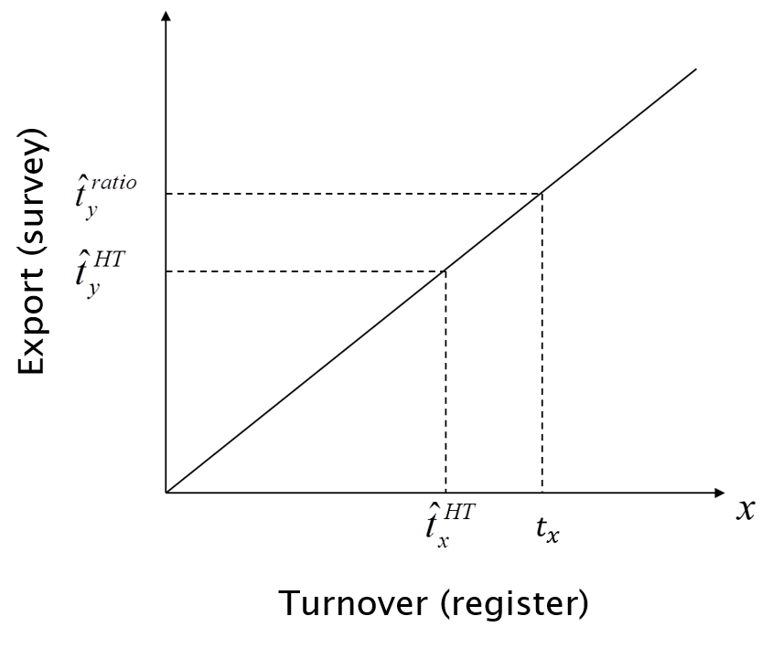

## The regression estimate

- The purpose of the regression estimate is to use an **auxiliary variable** \(x\) to get a better estimate of our **variable of interest** \(y\)
- **Better** means either
  - smaller standard error
  - or reduction of bias
- One can show that the regression etimate may be thought of as an **adjusted** HT-estimate:

\[ \hat{\tau}_y^{GREG} = \hat{\tau}_y^{HT} + (\tau_x - \hat{\tau}_x)\hat{\beta} \]

- Assume we know the **totals** of the auxiliary variable at the **population level** \[ \tau_x = \sum_{i \in \mathcal{U}}x_i \]
- We **could** also estimate these quantities from the sample applying the HT-estimator \[ \hat{\tau}_x^{HT}=\sum_{i \in \mathcal{S}}d_i x_i \]

  where \(d_i\) is the design weight for sample unit \(i\), ie. \(\frac{1}{\pi _i}\)
- Hopefully \(\hat{\tau}_x^{HT} \approx \tau_x\) but generally the two quantities will not be exactly equal
- In principle, this is unimportant, since we already know the true value
- But since the design weight \(d_i\) is also used for estimating totals for our variables of interest \(y\), we must expect these to be a little off, too – especially if \(y\) and \(x\) are correlated
- Hence, we seek a **calibrated weight** \(w_i\) such that the following calibration equation is satisfied \[ \sum_{i \in \mathcal{S}} w_i x_i = \tau_x \]
- The calibrated weights should ideally be close to the original design weights, so the calibrated weights are found as the solution to a **minimization** problem: \[ \min \sum_{i \in \mathcal{S}} G(w_i,d_i) \quad \textrm{subject to} \quad \sum_{i \in \mathcal{S}} w_i x_i = \tau_x \]
- \(G\) is a function measuring the distance between the design weight and the calibrated weight – for the regression estimate we use a quadratic distance function \[ G(w,d) = \frac{(w-d)^2}{2d} \]
- Now the regression estimate for our variable of interest \(y\) can simply be calculated as a weighted sum \[ \hat{\tau}_y^{GREG} = \sum_{i \in \mathcal{S}} w_i y_i \]
- The calibrated weight can be regarded as the design weight \(d_i\) multiplied with a \(g_i\)-weight (a factor introducing individual corrections) \[ w_i = g_i d_i \Rightarrow g_i = \frac{w_i}{d_i} \]
- Always check the \(g_i\)-weights – if there are **extreme values** check again what you are trying to accomplish with the calibration equations
- A third (and final) interpretation of the GREG-estimate (giving more prominence to an underlying linear model) is as the sum of predicted (or fitted) values for the entire population **plus** the design weighted residuals \[ \hat{\tau}_y^{GREG} = \sum_{i \in \mathcal{U}} \hat{y}_i + \sum_{i \in \mathcal{S}} d_i (y_i - \hat{y}_i) \]
- Calculating \(V(\hat{\tau}_y^{GREG})\) involves approximation by Taylor expansion and is generally best left to some suitable package in R…

## The regression estimate with R

Luclike, the survey package can do regression estimates, too.

We can use our register based employee information Nr_empl_reg or the turnover from last year, turnover_2019, to make regression estimates in our example.

We plot them against each other to see if there’s a correlation:

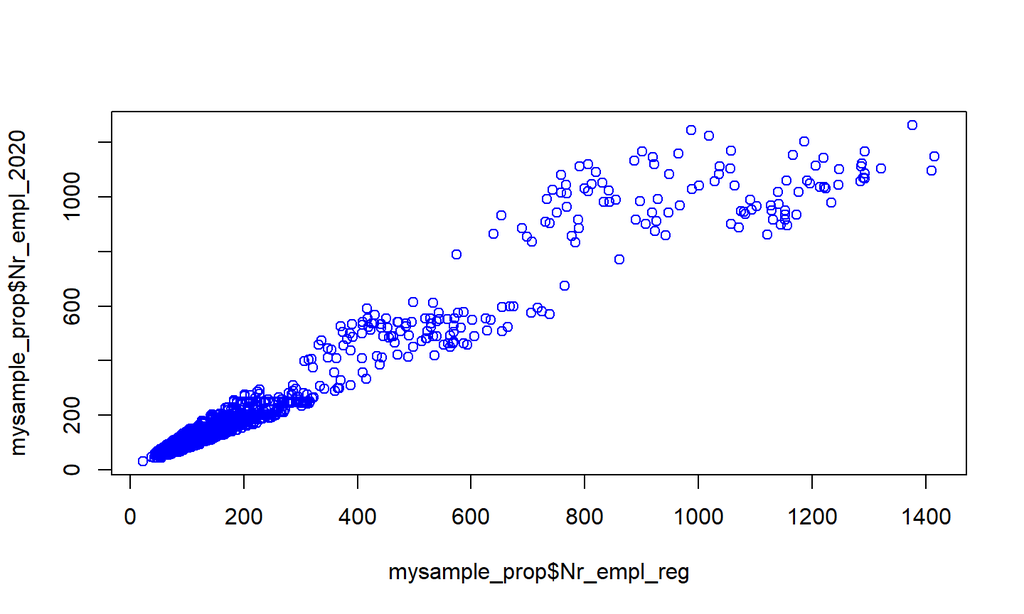

```r
plot(mysample_prop$Nr_empl_reg, mysample_prop$Nr_empl_2020, col = "blue")
```

Turnover has en even stronger correlation than number of employees:

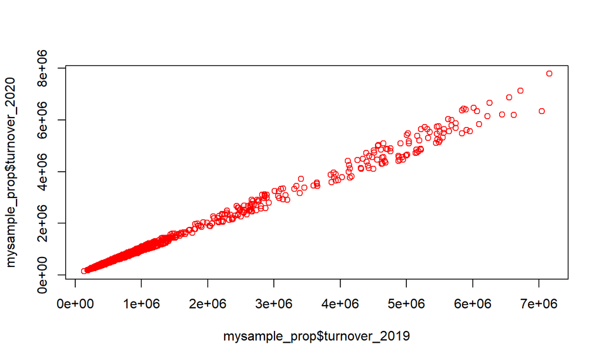

```r
plot(mysample_prop$turnover_2019, mysample_prop$turnover_2020, col = "red")
```

- We create a survey object from the optimal sample as well, and estimate both \(\tau_x\) and \(\tau_y\) using the `survey` package:

```r
load(file = "mysample_opt.Rda")

mysample_opt$dwgt <- 1/mysample_opt$Prob

srs.design.opt <- svydesign(ids=~1,
                        strata=~stratum,
                        weights=~dwgt,
                        fpc = ~Prob,
                        data=mysample_opt)
```

It looks a little different from the proportional one:

```r
summary(srs.design.opt)
```

```
## Stratified Independent Sampling design
## svydesign(ids = ~1, strata = ~stratum, weights = ~dwgt, fpc = ~Prob,
##     data = mysample_opt)
## Probabilities:
##    Min. 1st Qu.  Median    Mean 3rd Qu.    Max.
##  0.2000  0.2632  1.0000  0.7911  1.0000  1.0000
## Stratum Sizes:
##             1  2  3  4  5  6  7  8   9  10  11  12 13 14 15 16 17 18 19 20
## obs        15 14 14 15 24 27 21 23 206 178 172 184 10 10 10 10 22 18 20 15
## design.PSU 15 14 14 15 24 27 21 23 206 178 172 184 10 10 10 10 22 18 20 15
## actual.PSU 15 14 14 15 24 27 21 23 206 178 172 184 10 10 10 10 22 18 20 15
## Population stratum sizes (PSUs):
##   1  10  11  12  13  14  15  16  17  18  19   2  20   3   4   5   6   7   8   9
##  71 178 172 184  38  38  34  50 105  86  97  68  72  69  72 115 129 104 112 206
## Data variables:
##  [1] "sector"        "region"        "name"          "Nr_empl_reg"
##  [5] "turnover_2019" "turnover_2020" "Nr_empl_2020"  "stratum"
##  [9] "ID_unit"       "Prob"          "Stratum"       "dwgt"
```

```r
(to20.hat <- svytotal(~turnover_2020, srs.design.opt))
```

```
##                    total       SE
## turnover_2020 2631866885 19615527
```

```r
(to19.hat <- svytotal(~turnover_2019, srs.design.opt))
```

```
##                    total       SE
## turnover_2019 2631838390 19702929
```

We calculate the actual figures for comparison:

```
##     to2019     to2020
## 2633190649 2633045818
```

- We now turn to calibration (the regression estimate) and start by setting up a target consisting of the known population size and the known total of turnover_2019

```r
(cgoal <- c('(Intercept)'=nrow(mydata_example), 'turnover_2019'=sum(mydata_example$turnover_2019)))
```

```
##   (Intercept) turnover_2019
##          2000    2633190649
```

- Don’t worry too much about using named vectors – it is just syntax…
- The calibration is done by an aptly named function

```r
cal.svyobj <- calibrate (srs.design,
                         formula=~turnover_2019,
                         population=cgoal)

cal.svyobj.opt <- calibrate (srs.design.opt,
                         formula=~turnover_2019,
                         population=cgoal)
```

We use the new survey object to calculate a regression estimate of turnover_2019, although the result is known by definition in advance

```r
(to19.cal <- svytotal (~turnover_2019, cal.svyobj))
```

```
##                    total SE
## turnover_2019 2633190649  0
```

```r
(to19.cal.opt <- svytotal (~turnover_2019, cal.svyobj.opt))
```

```
##                    total SE
## turnover_2019 2633190649  0
```

- More interesting, we calculate the regression estimate of turnover_2020
- Now, we see the benefit of the optimal allocation - the standard error of the proportional allocation is almost twice as big as for the optimal allocation!

```r
(to20.cal <- svytotal (~turnover_2020, cal.svyobj))
```

```
##                    total      SE
## turnover_2020 2625779258 5065169
```

```r
(to20.cal.opt <- svytotal (~turnover_2020, cal.svyobj.opt))
```

```
##                    total      SE
## turnover_2020 2633216915 2997640
```

- We can get the calibrated weight (and also the \(g_i\)-weights) to gain some insight

```r
mysample_opt$cw <- weights(cal.svyobj.opt)
mysample_prop$cw <- weights(cal.svyobj)

mysample_opt$gw <- mysample_opt$cw / mysample_opt$dw
mysample_prop$gw <- mysample_prop$cw / mysample_prop$dw
```

Always remember to check your \(g_i\)’s - we want them to be close to 1, meaning that we haven’t changed the survey design too much.

The \(g_i\)’s from the proportional allocation are quite nice:

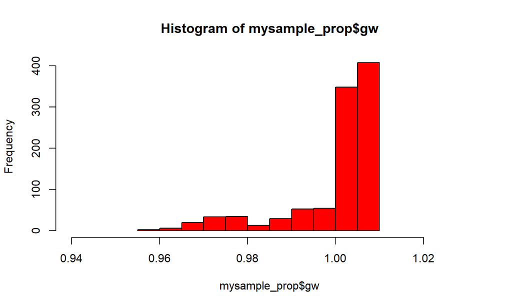

But again, the optimal allocation is even better:

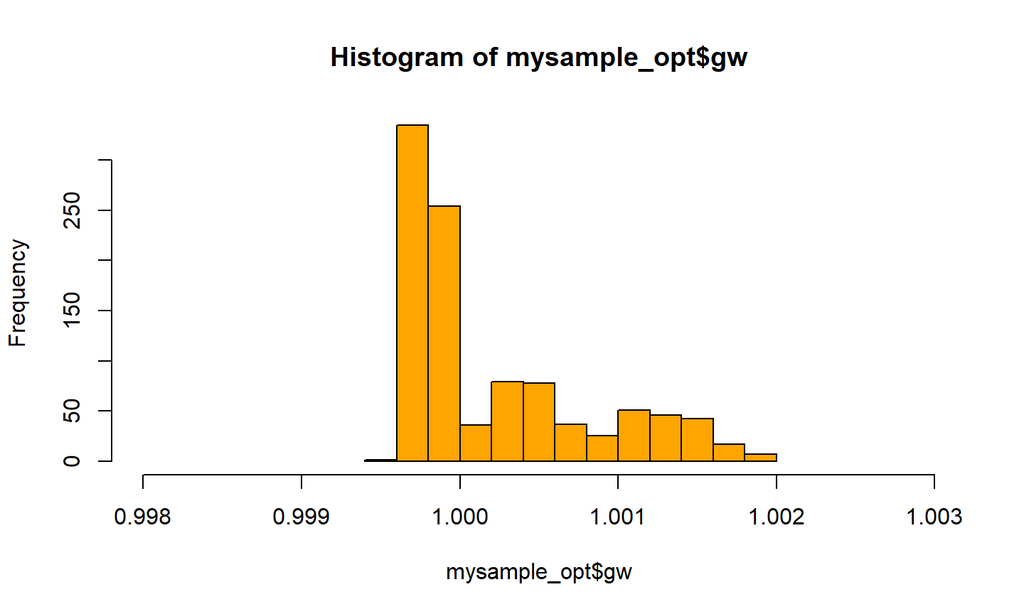

```r
hist(mysample_opt$gw, col = "orange", xlim = c(0.998, 1.003))
```

- Also note the following proporties

```r
sum(mysample_opt$dwgt)
```

```
## [1] 2000
```

```r
sum(mysample_opt$cw)
```

```
## [1] 2000
```

```r
mean(mysample_opt$gw)
```

```
## [1] 1.00021
```

One final comparison between proportional and optimal allocation:

```r
cv(to20.cal)
```

```
##               turnover_2020
## turnover_2020   0.001929015
```

```r
cv(to20.cal.opt)
```

```
##               turnover_2020
## turnover_2020   0.001138395
```

I suppose it’s becoming clear why we call it optimal allocation!